# ASSIGNMENT 6: Project - Neural Networks

### Make the necessary imports

```python
import tensorflow
import numpy as np
import matplotlib.pyplot as plt
import h5py
%matplotlib inline
from sklearn.model_selection import train_test_split
import skimage.transform as sk_transform
import skimage.filters as sk_filters
from skimage.transform import SimilarityTransform
from sklearn.metrics import classification_report
```

## Q1 Load Dataset

## Ans1

### Read the data file and import the data

```python
SVHN = h5py.File("SVHN_single_grey1.h5","r")
```

### Break the data into training + validation and testing sets.

## Note: The below set of statements "In [3]" is a part of Question 3

```python
X_train_val = SVHN["X_train"][:]
y_train_val = SVHN["y_train"][:]
X_test = SVHN["X_test"][:]
y_test = SVHN["y_test"][:]
```

### Close the file

```python
SVHN.close()
```

### View the data

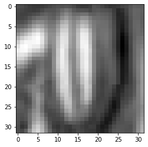

```python
plt.imshow(X_train_val[25], cmap = "gray")
```

```python
y_train_val[25]
```

```
0
```

## Q2 Understand the basic Image Classification pipeline and the data-driven approach (train/predict stages)

## Ans2

### Our approach and understanding of image classification

```
Below are the steps understood from our lectures
1. Data load and visualization - Understanding what the data looks like, in terms of shapes of the images, number  of channels, number of images and the level of clarity. This helps us understand the changes to our next steps. Specifically, this helps us determine if we need separate channel treatment, if we need to reduce images to a standard size and what kind of potential accuracy we may be looking at.
2. The next step is to preprocess the data and reduce it to unit standard deviation and zero mean. This helps to ensure faster convergence when we start training and testing.
3. After the preprocessing, it is important to check if we need to boost/augment the data. In complex data sets such as the current one, we may need augmentation to improve the final results and help the network cater for more possibilities
4. The next step would be to determine the architecture of the neural network itself and determine what functions and architecture would work best. Do we need ReLu functions or a combination of linear and other functions? How many neurons and how many layers to capture the features?
5. Then we need to see if we need to extract spatial correlations only (if the size of the data is large). If we need a degree of convolutions and filters to simplify the data.
6. After determining these, we need to test if our potential architecture works the way we need. We test it to overfit small samples, we test potential costs of learning rate changes and other hyperparameters by experimenting on small parts and samples of the data. Once we have these items cleared, we put together the network and start narrowing down on firmer ranges for our parameter values and start reinforcing our architecture decisions
7. finally, once we have it all in place and tested on small samples, we start working on it with larger data volumes and incorporate our discoveries.

This process continues iterating until we reach a level of performance which is satisfactory
```

# NOTE: Questions 3,4,5 are asnwered in the order -> Q5, Q4, Q3

## Q5 Implement batch normalization for training the neural network(10 points)

## Ans5

#### Develop the batching function. We have also added the Batch normalization here. We have also added additional normalization stages to the network itself.

```python
def minibatch (X, y, minibatch_size):
    n = X.shape[0]
    minibatches = []
    permutation = np.random.permutation(X.shape[0])
    X = X[permutation]
    y = y[permutation]

    for i in range(0, n, minibatch_size):
        X_batch = X[i:i + minibatch_size, :]
        X_batch = (X_batch - np.mean(X_batch))/(np.std(X_batch)+0.0000001) #Normalizing the minibatch
        y_batch = y[i:i + minibatch_size, ]
        minibatches.append((X_batch, y_batch))

    return minibatches
```

## Q4 Implement and apply a deep neural network classifier including (feedforward neural network, RELU, activations) (25 points)

## Ans4

### Develop a Neural Network Implementation

#### Develop the linear layer

```python
class Linear():
    def __init__(self, in_, out_):
        self.W = np.random.randn(in_,out_) * 0.01
        self.b = np.zeros((1,out_))
        self.params = [self.W, self.b]
        self.gradW = None
        self.gradb = None
        self.gradInput = None

    def forward(self, X):
        self.X = X
        self.output = np.dot(X, self.W) + self.b
        return self.output

    def backward(self, nextgrad):
        self.gradW = np.dot(self.X.T, nextgrad)
        self.gradb = np.sum(nextgrad, axis = 0)
        self.gradInput = np.dot(nextgrad, self.W.T)
        return self.gradInput, [self.gradW, self.gradb]
```

#### Develop a layer to normalize between layers. The backprop of this layer is a straight pass through

```python
class Normalize():
    def __init__(self):
        self.params = []
        self.gradInput = None

    def forward(self, X):
        self.output = (X - np.mean(X))/(np.std(X)+0.0000001)
        return self.output

    def backward(self, nextgrad):
        return nextgrad, []
```

#### Develop the ReLU layer

```python
class ReLU():
    def __init__(self):
        self.params = []
        self.gradInput = None

    def forward(self, X):
        self.output = np.maximum(X,0)
        return self.output

    def backward(self, nextgrad):
        self.gradInput = nextgrad.copy()
        self.gradInput [self.output<=0] = 0
        return self.gradInput, []
```

#### Develop the softmax function

```python
def softmax(X):
    exp_x = np.exp(X - np.max(X, axis = 1, keepdims = True))
    return exp_x/np.sum(exp_x, axis = 1, keepdims = True)
```

#### Create a CrossEntropy class as the loss function

```python
class CrossEntropy():
    def forward(self, X, y):
        self.m = y.shape[0]
        self.p = softmax(X)
        cross_entropy = -np.log(self.p[range(self.m),y])
        loss = np.sum(cross_entropy) /self.m
        return loss

    def backward(self, X, y):
        y_idx = y.argmax()
        grad = softmax(X)
        grad[range(self.m),y] -= 1
        grad /=self.m
        return grad
```

#### Develop the neural network itself

```python
class NN():
    def __init__(self, lossfunc = CrossEntropy()):
        self.params = []
        self.layers = []
        self.loss_func = lossfunc
        self.grads = []

    def add_layer(self, layer):
        self.layers.append(layer)
        self.params.append(layer.params)

    def forward(self, X):
        for layer in self.layers:
            X = layer.forward(X)
        return X

    def backward(self, nextgrad):
        self.clear_grad_param()
        for layer in reversed(self.layers):
            nextgrad, grad = layer.backward(nextgrad)
            self.grads.append(grad)
        return self.grads

    def train_step(self, X, y):
        out = self.forward(X)
        loss = self.loss_func.forward(out, y)
        nextgrad = self.loss_func.backward(out, y)
        grads = self.backward(nextgrad)
        return loss, grads

    def predict(self, X):
        X = self.forward(X)
        return np.argmax(X, axis = 1)

    def predict_scores(self, X):
        X = self.forward(X)
        return X

    def clear_grad_param(self):
        self.grads = []
```

#### Create a function to change the gradients based on learning rate and backprop

```python
def update_params(velocity, params, grads, learning_rate = 0.01, mu = 0.9, epoch=1):
    for v, p, g, in zip(velocity, params, reversed(grads)):
        for i in range(len(g)):
            v[i] = mu * v[i] + learning_rate * g[i]
            p[i] -= v[i]
```

```python
def train(net, X_train, y_train, minibatch_size, epoch, learning_rate, mu = 0.9, X_val=None, y_val = None):
    val_loss_epoch = []
    minibatches = minibatch(X_train, y_train, minibatch_size)
    minibatches_val = minibatch(X_val, y_val, minibatch_size)
    for i in range (epoch):
        loss_batch = []
        val_loss_batch = []
        velocity = []
        for param_layer in net.params:
            p = [np.zeros_like(param) for param in list(param_layer)]
            velocity.append(p)

        for X_mini, y_mini in minibatches:
            loss, grads = net.train_step(X_mini, y_mini)
            loss_batch.append(loss)
            update_params(velocity, net.params, grads, learning_rate = learning_rate, mu = mu, epoch = epoch)

        for X_mini_val, y_mini_val in minibatches_val:
            val_loss, _ = net.train_step(X_mini, y_mini)
            val_loss_batch.append(val_loss)

        m_train = X_train.shape[0]
        m_val = X_val.shape[0]

        y_train_pred = np.array([], dtype = "int64")
        y_val_pred = np.array([], dtype = "int64")
        y_train1 = []
        y_val1 = []
        for i in range(0, m_train, minibatch_size):
            X_tr = X_train[i:i + minibatch_size, :]
            y_tr = y_train[i:i + minibatch_size, ]
            y_train1 = np.append(y_train1, y_tr)
            y_train_pred = np.append(y_train_pred, net.predict(X_tr) )

        for i in range(0, m_val, minibatch_size):
            X_va = X_val[i:i + minibatch_size, :]
            y_va = y_val[i:i + minibatch_size, ]
            y_val1 = np.append(y_val1, y_va)
            y_val_pred = np.append(y_val_pred, net.predict(X_va) )

        train_acc = check_accuracy(y_train1, y_train_pred)
        val_acc = check_accuracy(y_train1, y_train_pred)

        mean_train_loss = sum(loss_batch)/float(len(loss_batch))
        mean_val_loss = sum(val_loss_batch)/float(len(val_loss_batch))

        val_loss_epoch.append(mean_val_loss)
        print ("validation loss", mean_val_loss, " Validation Accuracy ", val_acc)
        #if mean_val_loss < np.min(val_loss_epoch):
         #   best_net = net.deepcopy()
    return net
```

#### Check the Accuracy here

```python
def check_accuracy(y_true, y_pred):
    return (np.mean(y_true==y_pred))
```

## Q3 Data fetching and understand the train/val/test splits. (15 points)

## Ans3

### We have already fetched the data above. The data itself had training and testing splits. We will now further Split the train_val dataset into training and validation sets. Now we have all three, training, validation and testing

```python
X_train, X_val, y_train, y_val = train_test_split(X_train_val, y_train_val, test_size = 0.2)
train_dim = X_train.shape[0]
test_dim = X_test.shape[0]
val_dim = X_val.shape[0]
```

### We are augmenting the images here to create more data for our training. I wanted to bring in Horizontal flips, but later realized this was damaging the predictions for certain numbers

```python
#X_train_flip = np.fliplr(X_train) -- Removed as it was creating challenges
tform = SimilarityTransform(translation=(0, 2))
X_train_warp_up = []
j=0
for i in range(X_train.shape[0]):
    X_train_warp_up.append(sk_transform.warp(X_train[i], tform))
```

```python
tform = SimilarityTransform(translation=(0, -2))
X_train_warp_down = []
j=0
for i in range(X_train.shape[0]):
    X_train_warp_down.append(sk_transform.warp(X_train[i], tform))
```

```python
tform = SimilarityTransform(translation=(2, 0))
X_train_warp_left = []
j=0
for i in range(X_train.shape[0]):
    X_train_warp_left.append(sk_transform.warp(X_train[i], tform))
```

```python
tform = SimilarityTransform(translation=(-2, 0))
X_train_warp_right = []
j=0
for i in range(X_train.shape[0]):
    X_train_warp_right.append(sk_transform.warp(X_train[i], tform))
```

```python
tform = SimilarityTransform(translation=(2, 2))
X_train_warp_left_top = []
j=0
for i in range(X_train.shape[0]):
    X_train_warp_left_top.append(sk_transform.warp(X_train[i], tform))
```

```python
tform = SimilarityTransform(translation=(2, -2))
X_train_warp_left_bottom = []
j=0
for i in range(X_train.shape[0]):
    X_train_warp_left_bottom.append(sk_transform.warp(X_train[i], tform))
```

```python
tform = SimilarityTransform(translation=(-2, 2))
X_train_warp_right_top = []
j=0
for i in range(X_train.shape[0]):
    X_train_warp_right_top.append(sk_transform.warp(X_train[i], tform))
```

```python
tform = SimilarityTransform(translation=(-2, -2))
X_train_warp_right_bottom = []
j=0
for i in range(X_train.shape[0]):
    X_train_warp_right_bottom.append(sk_transform.warp(X_train[i], tform))
```

### Convert all of it to Np Arrays

```python
X_train_warp_up = np.array(X_train_warp_up)
X_train_warp_right = np.array(X_train_warp_right)
X_train_warp_left = np.array(X_train_warp_left)
X_train_warp_down = np.array(X_train_warp_down)
X_train_warp_left_top = np.array(X_train_warp_left_top)
X_train_warp_right_top = np.array(X_train_warp_right_top)
X_train_warp_left_bottom = np.array(X_train_warp_left_bottom)
X_train_warp_right_bottom = np.array(X_train_warp_right_bottom)
```

### We have now merged the different datasets created into one

```python
random_value = np.random.randint(100)*0.01
X_train_final = np.concatenate([X_train, X_train+random_value, X_train_warp_up,X_train_warp_right,
        X_train_warp_left,X_train_warp_down,X_train_warp_left_top,
        X_train_warp_right_top,X_train_warp_left_bottom,X_train_warp_right_bottom], axis = 0)
```

```python
X_train_final.shape
```

```
(336000, 32, 32)
```

### We have now merged the different target sets into one

```python
y_train_final = np.concatenate([y_train,y_train,y_train,y_train,y_train,y_train,y_train,y_train,y_train,y_train], axis =0 )
```

```python
y_train_final.shape
```

```
(336000,)
```

### Testing if the changes look as intended

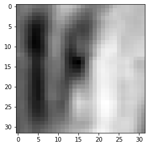

```python
plt.imshow(X_train_final[24].reshape(32,32), cmap = "gray")
```

### Reshape images to 1 d and normalize

```python
#X_train = X_train.reshape(train_dim,1024)
X_train_final = X_train_final.reshape(train_dim*10,1024)
#X_train_warp_right = X_train_warp_right.reshape(train_dim,1024)
#X_train_warp_left = X_train_warp_left.reshape(train_dim,1024)
#X_train_warp_up = X_train_warp_up.reshape(train_dim,1024)
#X_train_warp_down = X_train_warp_down.reshape(train_dim,1024)
#X_train_warp_left_top = X_train_warp_left_top.reshape(train_dim,1024)
#X_train_warp_right_top = X_train_warp_right_top.reshape(train_dim,1024)
#X_train_warp_left_bottom = X_train_warp_left_bottom.reshape(train_dim,1024)
#X_train_warp_right_bottom = X_train_warp_right_bottom.reshape(train_dim,1024)
X_test = X_test.reshape(test_dim,1024)
X_val = X_val.reshape(val_dim,1024)
X_train_final = (X_train_final - np.mean(X_train_final))/(np.std(X_train_final)+0.0000001)
X_train = (X_train - np.mean(X_train))/(np.std(X_train)+0.0000001)
X_test = (X_test - np.mean(X_test))/(np.std(X_test)+0.0000001)
X_val = (X_val - np.mean(X_val))/(np.std(X_val)+0.0000001)
```

### Discover the right parameters

#### We experiment here with a few learning rates to see what works

#### Learning Rate: 10

```python
input_dim = X_train_final.shape[1]

iterations = 10
learning_rate = 10
hidden_nodes = 48
output_nodes = 10

nn = NN()
nn.add_layer(Linear(input_dim, hidden_nodes))
nn.add_layer(Normalize())
nn.add_layer(ReLU())
nn.add_layer(Normalize())
nn.add_layer(Linear(hidden_nodes, output_nodes))

nn = train(nn, X_train_final, y_train_final, minibatch_size=500,
           epoch = 10, learning_rate= learning_rate, X_val = X_val, y_val = y_val)
```

```
validation loss 19.18592111991513  Validation Accuracy  0.31270238095238095
validation loss 7.345491776491927  Validation Accuracy  0.4409375
validation loss 7.041574510955318  Validation Accuracy  0.4664672619047619
validation loss 6.421455666935998  Validation Accuracy  0.47319940476190475
validation loss 5.565261626966621  Validation Accuracy  0.4800654761904762
validation loss 5.978520733242064  Validation Accuracy  0.5082440476190476
validation loss 6.348569814410637  Validation Accuracy  0.5164940476190476
validation loss 6.72550600577539  Validation Accuracy  0.48932738095238093
validation loss 7.161574968787392  Validation Accuracy  0.48588095238095236
validation loss 5.5477121288719164  Validation Accuracy  0.5209494047619048
```

#### OBSERVATION: This learning rate is too high and is not resulting in a rapid improvement in accuracy

#### Learning Rate: 1

```python
input_dim = X_train_final.shape[1]

iterations = 10
learning_rate = 1
hidden_nodes = 48
output_nodes = 10

nn = NN()
nn.add_layer(Linear(input_dim, hidden_nodes))
nn.add_layer(Normalize())
nn.add_layer(ReLU())
nn.add_layer(Normalize())
nn.add_layer(Linear(hidden_nodes, output_nodes))

nn = train(nn, X_train_final, y_train_final, minibatch_size=500,
           epoch = 10, learning_rate= learning_rate, X_val = X_val, y_val = y_val)
```

```
validation loss 1.4424255305366673  Validation Accuracy  0.5409553571428571
validation loss 1.0777071521884058  Validation Accuracy  0.6835922619047619
validation loss 0.9552584373177135  Validation Accuracy  0.7143511904761904
validation loss 0.8560401935079974  Validation Accuracy  0.7325744047619047
validation loss 0.8098457523391969  Validation Accuracy  0.7422678571428571
validation loss 0.8058696732421535  Validation Accuracy  0.7462291666666667
validation loss 0.7941352900672063  Validation Accuracy  0.7535119047619048
validation loss 0.7813046672211718  Validation Accuracy  0.7592946428571429
validation loss 0.7742292700567737  Validation Accuracy  0.7655446428571429
validation loss 0.7603369571189358  Validation Accuracy  0.7674970238095238
```

#### OBSERVATION: This learning rate does provide some improvement over the base accuracy

#### Learning Rate: 0.1

```python
input_dim = X_train_final.shape[1]

iterations = 10
learning_rate = 0.1
hidden_nodes = 48
output_nodes = 10

nn = NN()
nn.add_layer(Linear(input_dim, hidden_nodes))
nn.add_layer(Normalize())
nn.add_layer(ReLU())
nn.add_layer(Normalize())
nn.add_layer(Linear(hidden_nodes, output_nodes))

nn = train(nn, X_train_final, y_train_final, minibatch_size=500,
           epoch = 10, learning_rate= learning_rate, X_val = X_val, y_val = y_val)
```

```
validation loss 0.9077481089149638  Validation Accuracy  0.7086071428571429
validation loss 0.8538135449562888  Validation Accuracy  0.73975
validation loss 0.7921129106006825  Validation Accuracy  0.77375
validation loss 0.7625440779359287  Validation Accuracy  0.7866071428571428
validation loss 0.7611366593025457  Validation Accuracy  0.7921458333333333
validation loss 0.7595668295330922  Validation Accuracy  0.7972440476190477
validation loss 0.746975864100296  Validation Accuracy  0.8010267857142858
validation loss 0.7327886835057241  Validation Accuracy  0.8038958333333334
validation loss 0.7247093139428687  Validation Accuracy  0.8060386904761905
validation loss 0.7184483531566711  Validation Accuracy  0.8081964285714286
```

#### OBSERVATION: This learning rate shows rapid convergence towards a high accuracy

#### Learning Rate: 0.01

```python
input_dim = X_train_final.shape[1]

iterations = 10
learning_rate = 0.01
hidden_nodes = 48
output_nodes = 10

nn = NN()
nn.add_layer(Linear(input_dim, hidden_nodes))
nn.add_layer(Normalize())
nn.add_layer(ReLU())
nn.add_layer(Normalize())
nn.add_layer(Linear(hidden_nodes, output_nodes))

nn = train(nn, X_train_final, y_train_final, minibatch_size=500,
           epoch = 10, learning_rate= learning_rate, X_val = X_val, y_val = y_val)
```

```
validation loss 1.2286267702034528  Validation Accuracy  0.6364583333333333
validation loss 1.0214639687314744  Validation Accuracy  0.7085654761904762
validation loss 0.9275952241979565  Validation Accuracy  0.7414315476190476
validation loss 0.8711496082350845  Validation Accuracy  0.7579047619047619
validation loss 0.835565246524054  Validation Accuracy  0.7686845238095238
validation loss 0.8110285255817469  Validation Accuracy  0.7759345238095238
validation loss 0.7927720973117373  Validation Accuracy  0.7816934523809523
validation loss 0.7781940944956359  Validation Accuracy  0.7867559523809524
validation loss 0.7684687278101447  Validation Accuracy  0.7899642857142857
validation loss 0.759617937003266  Validation Accuracy  0.7930595238095238
```

#### OBSERVATION: This learning rate is mildly slower than 0.1. We would prefer to proceed with a region around 0.1 as a learning rate

### Train the network

#### Note: We used some experiments to arrive at a final learning rate of 0.3 and a minibatch size of 500. This helps us gain optimum training traction.

```python
input_dim = X_train_final.shape[1]

iterations = 10
learning_rate = 0.3
hidden_nodes = 48
output_nodes = 10

nn = NN()
nn.add_layer(Linear(input_dim, hidden_nodes))
nn.add_layer(Normalize())
nn.add_layer(ReLU())
nn.add_layer(Normalize())
nn.add_layer(Linear(hidden_nodes, output_nodes))

nn = train(nn, X_train_final, y_train_final, minibatch_size=500,
           epoch = 200, learning_rate= learning_rate, X_val = X_val, y_val = y_val)
```

```
validation loss 0.8970446141283888  Validation Accuracy  0.7028779761904762
validation loss 0.7746010917287335  Validation Accuracy  0.7501517857142858
validation loss 0.745068271406669  Validation Accuracy  0.7630148809523809
validation loss 0.7329009185184804  Validation Accuracy  0.7669494047619048
validation loss 0.695357952496949  Validation Accuracy  0.7772380952380953
validation loss 0.6737875197640764  Validation Accuracy  0.7867529761904762
validation loss 0.6612348246070316  Validation Accuracy  0.7906726190476191
validation loss 0.6535677938611143  Validation Accuracy  0.7940357142857143
validation loss 0.6446342755978337  Validation Accuracy  0.7961130952380953
validation loss 0.6380861323520548  Validation Accuracy  0.7975
validation loss 0.6420558693775055  Validation Accuracy  0.7988303571428571
validation loss 0.6439276617702909  Validation Accuracy  0.7997589285714286
validation loss 0.6422161082202215  Validation Accuracy  0.801157738095238
validation loss 0.639939672057867  Validation Accuracy  0.803764880952381
validation loss 0.6402487296332697  Validation Accuracy  0.8031696428571429
validation loss 0.636486926643716  Validation Accuracy  0.8048095238095239
validation loss 0.6333333819149971  Validation Accuracy  0.8057946428571429
validation loss 0.6343376748612168  Validation Accuracy  0.8062589285714286
validation loss 0.633096479618122  Validation Accuracy  0.8065952380952381
validation loss 0.6282801358479227  Validation Accuracy  0.8082083333333333
validation loss 0.6235266504212672  Validation Accuracy  0.8094613095238096
validation loss 0.6248847861092803  Validation Accuracy  0.8092708333333334
validation loss 0.6222302821142771  Validation Accuracy  0.8112678571428571
validation loss 0.6212432966584883  Validation Accuracy  0.8129880952380952
validation loss 0.6205481389190719  Validation Accuracy  0.811985119047619
validation loss 0.6227207334220939  Validation Accuracy  0.8121994047619048
validation loss 0.6183418784508887  Validation Accuracy  0.8139404761904762
validation loss 0.6197925249975834  Validation Accuracy  0.8142380952380952
validation loss 0.6190392386477386  Validation Accuracy  0.8148422619047619
validation loss 0.6164485261711234  Validation Accuracy  0.8153244047619047
validation loss 0.6180195637727978  Validation Accuracy  0.8157440476190476
validation loss 0.6122957259642388  Validation Accuracy  0.8168363095238095
validation loss 0.6157679277491839  Validation Accuracy  0.8162232142857143
validation loss 0.6122572596788853  Validation Accuracy  0.8173541666666667
validation loss 0.6136730600873002  Validation Accuracy  0.8172827380952381
validation loss 0.6123162488845323  Validation Accuracy  0.8179494047619048
validation loss 0.6128655346296038  Validation Accuracy  0.8177380952380953
validation loss 0.6103787678097652  Validation Accuracy  0.8183928571428571
validation loss 0.6121014704347958  Validation Accuracy  0.8179196428571428
validation loss 0.6110226324361002  Validation Accuracy  0.8184523809523809
```

[output cut: 145 more lines]

```
validation loss 0.5885609147749056  Validation Accuracy  0.8282142857142857
validation loss 0.5891666801341218  Validation Accuracy  0.8282261904761905
validation loss 0.5877425544111292  Validation Accuracy  0.8283005952380952
validation loss 0.588527651000401  Validation Accuracy  0.8283184523809524
validation loss 0.588926064452447  Validation Accuracy  0.8282232142857143
validation loss 0.588989075108809  Validation Accuracy  0.8283809523809523
validation loss 0.5888857628128887  Validation Accuracy  0.8282797619047619
validation loss 0.5881996529353656  Validation Accuracy  0.8281011904761905
validation loss 0.5887344996650263  Validation Accuracy  0.8282827380952381
validation loss 0.5876326944719673  Validation Accuracy  0.8284136904761905
validation loss 0.5876770497297426  Validation Accuracy  0.8283601190476191
validation loss 0.5876842031094186  Validation Accuracy  0.8283244047619047
validation loss 0.5870458100732263  Validation Accuracy  0.8283779761904762
validation loss 0.5878373820290215  Validation Accuracy  0.8282827380952381
validation loss 0.5872283602111333  Validation Accuracy  0.8284761904761905
```

### Run the predictions

```python
y_pred = nn.predict(X_test)
```

## Q6 Print the classification accuracy metrics (10 points)

## Ans6

### Classification accuracy metrics

```python
check_accuracy(y_test, y_pred)
```

```
0.8470555555555556
```

```python
print(classification_report(y_test, y_pred))
```

```
              precision    recall  f1-score   support

           0       0.84      0.91      0.87      1814
           1       0.79      0.87      0.83      1828
           2       0.88      0.87      0.87      1803
           3       0.82      0.77      0.80      1719
           4       0.86      0.88      0.87      1812
           5       0.83      0.84      0.84      1768
           6       0.86      0.82      0.84      1832
           7       0.91      0.87      0.89      1808
           8       0.85      0.81      0.83      1812
           9       0.85      0.82      0.83      1804

    accuracy                           0.85     18000
   macro avg       0.85      0.85      0.85     18000
weighted avg       0.85      0.85      0.85     18000
```

```python
from sklearn.metrics import confusion_matrix
import seaborn as sns
```

```python
print(confusion_matrix(y_test, y_pred))
```

```
[[1650   32   14   11   26    3   14   18   13   33]
 [  44 1596   21   26   45    7   11   37   22   19]
 [  23   39 1571   40   28    5    6   38   17   36]
 [  19   45   38 1332   20  130   15   17   63   40]
 [  17   66   24   13 1598   16   20   10   18   30]
 [  12   19   12   68   21 1490   80    9   23   34]
 [  65   23    8   12   48   70 1502   10   72   22]
 [  21  106   39   29   15   12    3 1565    6   12]
 [  37   52   19   48   34   26   77   10 1464   45]
 [  88   35   43   38   23   35   20   12   31 1479]]
```

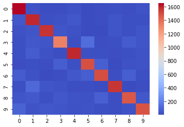

```python
sns.heatmap(confusion_matrix(y_test, y_pred), cmap ="coolwarm")
```

#### OBSERVATION: our final accuracy, though not stellar, seems to work well for a complex data set and a limited set of neurons. our performance on the untouched test set was above 84%

# Additional Section: Developing NN with tensorflow

## Q4 Implement and apply a deep neural network classifier including (feedforward neural network, RELU, activations) (25 points)

## Ans4 - Alternative Answer

### Making TF imports

```python
from tensorflow.keras.models import Sequential
from tensorflow.keras.layers import Dense, BatchNormalization
from tensorflow.keras import regularizers, optimizers
```

### Creating a model and its corresponding scoring function. Added batch normalization layer here as well. (Part of question 5)

```python
def train_test_loop(iter, lr, Lambda, X_train_, y_train_, X_val_, y_val_, verb = True):
    iterations = iter
    learning_rate = lr
    hidden_nodes = 256
    output_nodes = 10

    model = Sequential()
    model.add(BatchNormalization(input_shape = (1024,)))
    model.add(Dense(hidden_nodes , input_shape = (1024,), activation  = "relu"))
    model.add(Dense(hidden_nodes ,activation  = "relu"))
    model.add(Dense(output_nodes , activation  = "softmax", kernel_regularizer=regularizers.l2(Lambda)))

    sgd = optimizers.SGD(lr = learning_rate, decay = 1e-6, momentum = 0.9)

    model.compile(loss="categorical_crossentropy", optimizer = sgd, metrics = ["accuracy"])
    print(X_train_.shape)
    print(y_train_.shape)
    model.fit(X_train_, y_train_, epochs = iterations, batch_size = 1000, verbose = 1)
    score = model.evaluate(X_val_, y_val_, verbose = 0)
    return score, model
```

### Trying a low learning rate to see if the training fails

#### Learning Rate 1e-5

```python
from keras.utils import to_categorical
Lambda = 0
lr = 1e-5
y_train_fin = to_categorical(y_train_final)
y_val_ = to_categorical(y_val)
train_test_loop(5, lr, Lambda, X_train_final, y_train_fin, X_val, y_val_)
```

```
(336000, 1024)
(336000, 10)
```

```
([2.369180917739868, 0.11523809283971786],
 <tensorflow.python.keras.engine.sequential.Sequential at 0x1969fa1d358>)
```

### Trying a high learning rate to see if the training fails

#### Learning Rate 1e+2

```python
Lambda = 0
lr = 1e+2
y_train_fin = to_categorical(y_train_final)
y_val_ = to_categorical(y_val)
train_test_loop(5, lr, Lambda, X_train_final, y_train_fin, X_val, y_val_)
```

```
(336000, 1024)
(336000, 10)
```

```
([nan, 0.09952381253242493],
 <tensorflow.python.keras.engine.sequential.Sequential at 0x196bc2c6828>)
```

#### OBSERVATION: Very Low learning rate ensures there is no training and accuracy remains poor. While a higher learning rate ensures that the loss explodes

### Now trying an overfit on a smaller dataset to see if we got the architecture right

```python
X_train_sub = X_train_final[:1000]
y_train_sub = y_train_final[:1000]
```

```python
Lambda = 0
lr = 1e-2
y_train_fin = to_categorical(y_train_sub)
y_val_ = to_categorical(y_val)
train_test_loop(500, lr, Lambda, X_train_sub, y_train_fin, X_val, y_val_)
```

```
(1000, 1024)
(1000, 10)
```

```
([2.251131534576416, 0.5330952405929565],
 <tensorflow.python.keras.engine.sequential.Sequential at 0x196be9fd978>)
```

#### OBSERVATION: We overfit very quickly. Thus we are on the right track

### Experimenting with different Lambda values to see what converges faster

#### Lambda 0.002

```python
Lambda = 0.002
lr = 0.02
y_train_fin = to_categorical(y_train_final)
y_val_ = to_categorical(y_val)
train_test_loop(20, lr, Lambda, X_train_final, y_train_fin, X_val, y_val_)
```

```
(336000, 1024)
(336000, 10)
```

```
([0.4736008942127228, 0.8865476250648499],
 <tensorflow.python.keras.engine.sequential.Sequential at 0x196bc7cc400>)
```

#### Lambda 0.02

```python
Lambda = 0.02
lr = 0.02
y_train_fin = to_categorical(y_train_final)
y_val_ = to_categorical(y_val)
train_test_loop(20, lr, Lambda, X_train_final, y_train_fin, X_val, y_val_)
```

```
(336000, 1024)
(336000, 10)
```

```
([0.4483555257320404, 0.8858333230018616],
 <tensorflow.python.keras.engine.sequential.Sequential at 0x196bebd4940>)
```

#### Lambda 0.0002

```python
Lambda = 0.0002
lr = 0.02
y_train_fin = to_categorical(y_train_final)
y_val_ = to_categorical(y_val)
train_test_loop(20, lr, Lambda, X_train_final, y_train_fin, X_val, y_val_)
```

```
(336000, 1024)
(336000, 10)
```

```
([0.5100357532501221, 0.878333330154419],
 <tensorflow.python.keras.engine.sequential.Sequential at 0x196c2439710>)
```

#### Lambda 0.00002

```python
Lambda = 0.00002
lr = 0.02
y_train_fin = to_categorical(y_train_final)
y_val_ = to_categorical(y_val)
train_test_loop(20, lr, Lambda, X_train_final, y_train_fin, X_val, y_val_)
```

```
(336000, 1024)
(336000, 10)
```

```
([0.5132913589477539, 0.8791666626930237],
 <tensorflow.python.keras.engine.sequential.Sequential at 0x196bef1f1d0>)
```

### Experimenting with different Learning Rate values to see what converges faster

#### Learning Rate 0.2

```python
Lambda = 0.0002
lr = 0.2
y_train_fin = to_categorical(y_train_final)
y_val_ = to_categorical(y_val)
train_test_loop(20, lr, Lambda, X_train_final, y_train_fin, X_val, y_val_)
```

```
(336000, 1024)
(336000, 10)
```

```
([0.5468409657478333, 0.8722618818283081],
 <tensorflow.python.keras.engine.sequential.Sequential at 0x196d50c5828>)
```

#### Learning Rate 0.002

```python
Lambda = 0.0002
lr = 0.002
y_train_fin = to_categorical(y_train_final)
y_val_ = to_categorical(y_val)
train_test_loop(20, lr, Lambda, X_train_final, y_train_fin, X_val, y_val_)
```

```
(336000, 1024)
(336000, 10)
```

```
([0.5128769278526306, 0.8616666793823242],
 <tensorflow.python.keras.engine.sequential.Sequential at 0x196c2860710>)
```

### Now Narrowing the range down to around 0.02

#### Learning Rate 0.01

```python
Lambda = 0.0002
lr = 0.01
y_train_fin = to_categorical(y_train_final)
y_val_ = to_categorical(y_val)
train_test_loop(20, lr, Lambda, X_train_final, y_train_fin, X_val, y_val_)
```

```
(336000, 1024)
(336000, 10)
```

```
([0.47104471921920776, 0.882023811340332],
 <tensorflow.python.keras.engine.sequential.Sequential at 0x196c3d63da0>)
```

#### Learning Rate 0.03

```python
Lambda = 0.0002
lr = 0.03
y_train_fin = to_categorical(y_train_final)
y_val_ = to_categorical(y_val)
train_test_loop(20, lr, Lambda, X_train_final, y_train_fin, X_val, y_val_)
```

```
(336000, 1024)
(336000, 10)
```

```
([0.5407624244689941, 0.8788095116615295],
 <tensorflow.python.keras.engine.sequential.Sequential at 0x196c43b7470>)
```

#### Learning Rate 0.05

```python
Lambda = 0.0002
lr = 0.05
y_train_fin = to_categorical(y_train_final)
y_val_ = to_categorical(y_val)
train_test_loop(20, lr, Lambda, X_train_final, y_train_fin, X_val, y_val_)
```

```
(336000, 1024)
(336000, 10)
```

```
([0.5645659565925598, 0.8780952095985413],
 <tensorflow.python.keras.engine.sequential.Sequential at 0x196c4281588>)
```

#### OBSERVATION: our experiments suggest we should proceed with a learning rate of 0.01 or 0.02. Higher learning rates are overfitting the images

### Final NN training and fitment

```python
Lambda = 2e-4
lr = 2e-2
y_train_fin = to_categorical(y_train_final)
y_val_ = to_categorical(y_val)
(score, final_model) = train_test_loop(150, lr, Lambda, X_train_final, y_train_fin, X_val, y_val_)
```

```
(336000, 1024)
(336000, 10)
```

#### OBSERVATION: The power of a 256 neuron network is such that it can easily fit over three hundred thousand different images. This renders the learning rate and lambda tuning slightly pointless. As long as we can do a coarse grained evaluation and find a proper zone, the network will eventually fit itself

### Making predictions

```python
y_pred_final = final_model.predict(X_test)
```

```python
y_pred_final.shape
```

```
(18000, 10)
```

```python
import array
```

### Convert the output into an array

```python
y_pred_fin = array.array('I', [])
for pred in y_pred_final:
    y_pred_fin.append(np.argmax(pred))
```

## Q6 Print the classification accuracy metrics (10 points)

## Ans6 - Alternative Answer

### Sharing the classification accuracy metrics

```python
np.mean(y_test == y_pred_fin)
```

```
0.8791666666666667
```

```python
print(classification_report(np.array(y_test), np.array(y_pred_fin)))
```

```
              precision    recall  f1-score   support

           0       0.90      0.92      0.91      1814
           1       0.87      0.89      0.88      1828
           2       0.89      0.90      0.90      1803
           3       0.81      0.85      0.83      1719
           4       0.90      0.92      0.91      1812
           5       0.86      0.88      0.87      1768
           6       0.89      0.86      0.87      1832
           7       0.93      0.91      0.92      1808
           8       0.86      0.83      0.85      1812
           9       0.90      0.85      0.87      1804

    accuracy                           0.88     18000
   macro avg       0.88      0.88      0.88     18000
weighted avg       0.88      0.88      0.88     18000
```

```python
print(confusion_matrix(np.array(y_test), np.array(y_pred_fin)))
```

```
[[1661   27   14   20   15    8   21    9   13   26]
 [  30 1621   20   25   47   12   10   33   19   11]
 [   9   21 1619   45   24   12    2   30   12   29]
 [  12   23   28 1461   11   75   19   18   45   27]
 [  13   35   17   24 1666    7   14   10   10   16]
 [   7   13   13   75   12 1553   48    7   26   14]
 [  39   13   13   11   33   65 1568    8   69   13]
 [  11   57   29   26   15    9    8 1637    5   11]
 [  23   33   21   75   17   27   68    5 1511   32]
 [  45   21   36   49   19   33   13   12   48 1528]]
```

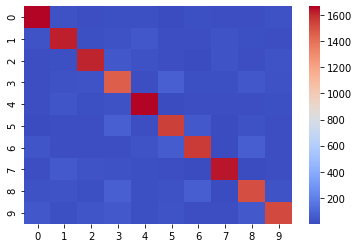

```python
sns.heatmap(confusion_matrix(np.array(y_test), np.array(y_pred_fin)), cmap ="coolwarm")
```